# Lesson 1 - Exploratory Data Analysis: Import, Inspect, and Visualize Data

## Plotting data

You should never only look at number! Plotting data is a great method to learn more about your data. We’ll practice more with this later, but the following functions are always useful for getting a sense of what your data look like. We’ll spend more time with {ggplot2}, the corvette of R plotting shortly. But for now, let’s start with some base R functions: `plot` and `hist`.

Plot is the all purpose workhorse built into R. Most packages have an addition to `plot` that makes it useful for whatever type of data you have. Below are a few examples of how you can use this. First, you can plot all values of a single variable. Next, `plot` makes bivariate scatter plots when supplied with two numeric variables. Finally, plot can provide plots of analyses under most situations.

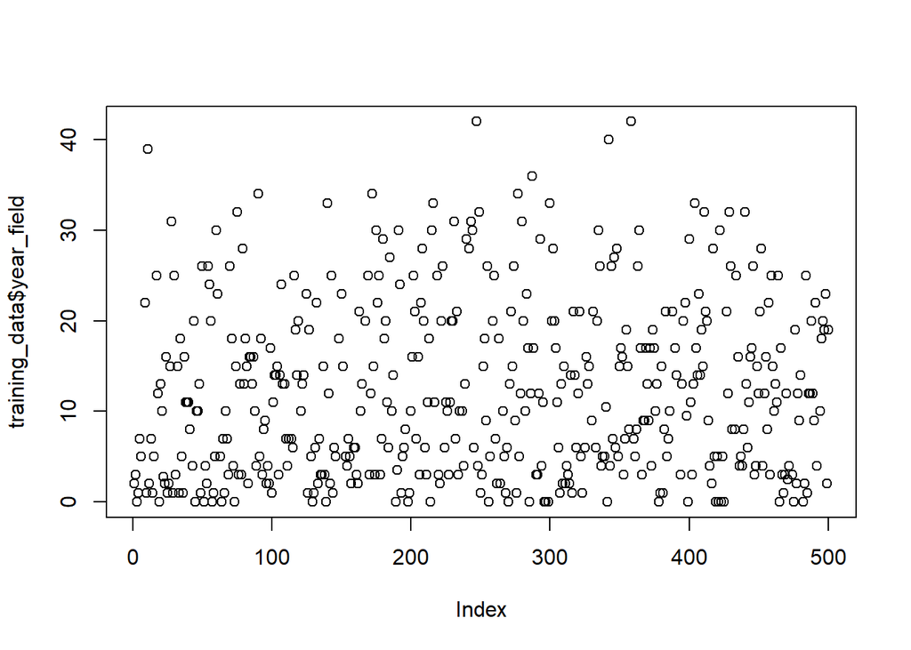

```r
# Single variable Plot
# The $ is called an atomic operator. You can select a smaller piece of a larger object with it. In this case, the data `training_data` is the large object, and column `year_field` is the smaller object.
plot(training_data$year_field)
```

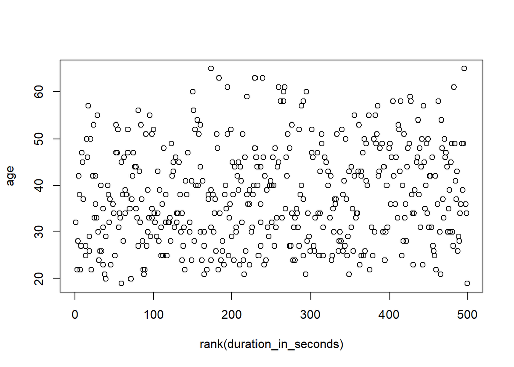

```r
# Bivariate Scatter Plot
# Here `with` tells R which object to use, then you only supply plot with the columns of interest.
#`rank` transforms the `duration_in_seconds` column into a rank ordered variable.
with(training_data,
     plot(rank(duration_in_seconds), age)
     )
```

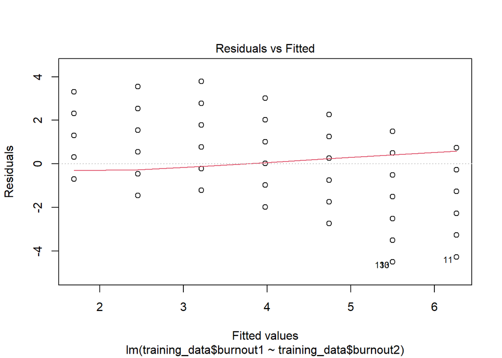

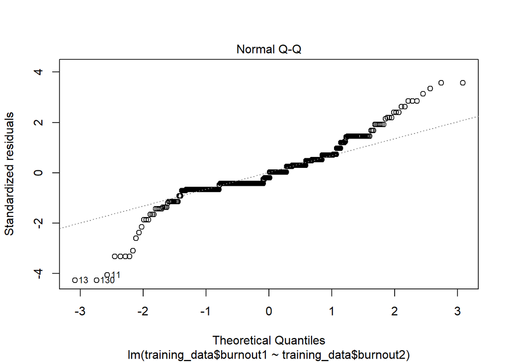

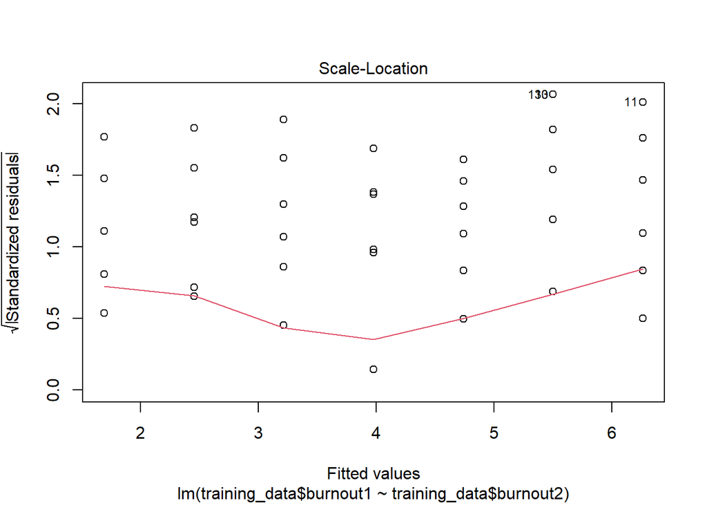

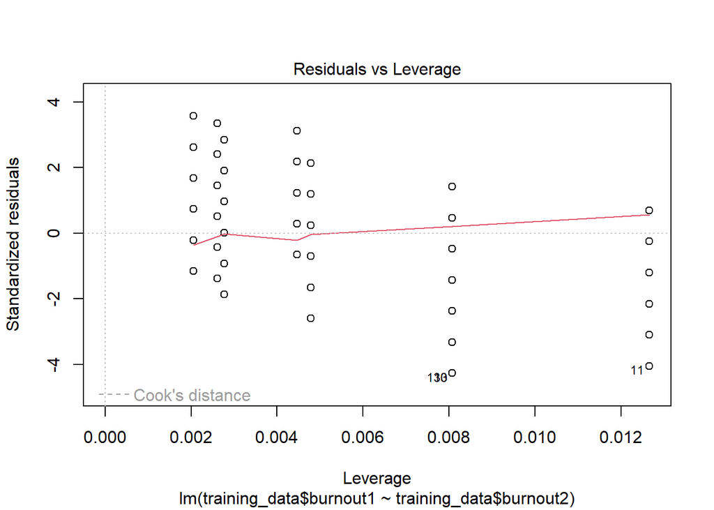

```r
# `lm` performs and OLS linear regression, and `plot` produces summary plots.
plot(
  lm(training_data$burnout1 ~ training_data$burnout2)
  )
```

Histograms are another useful way to evaluate data. A histogram “bins” data and gives you a count of the number of responses per bin. You can see a few examples below.

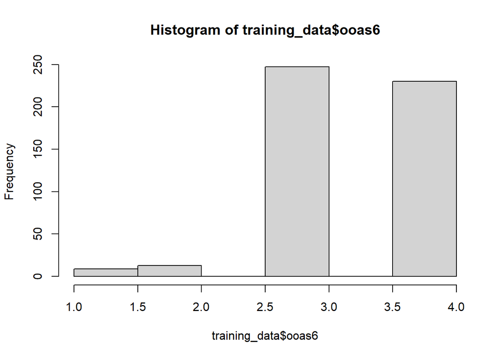

```r
# This is an unattractive histogram of one of the variables from our dataset.
hist(training_data$ooas6)
```

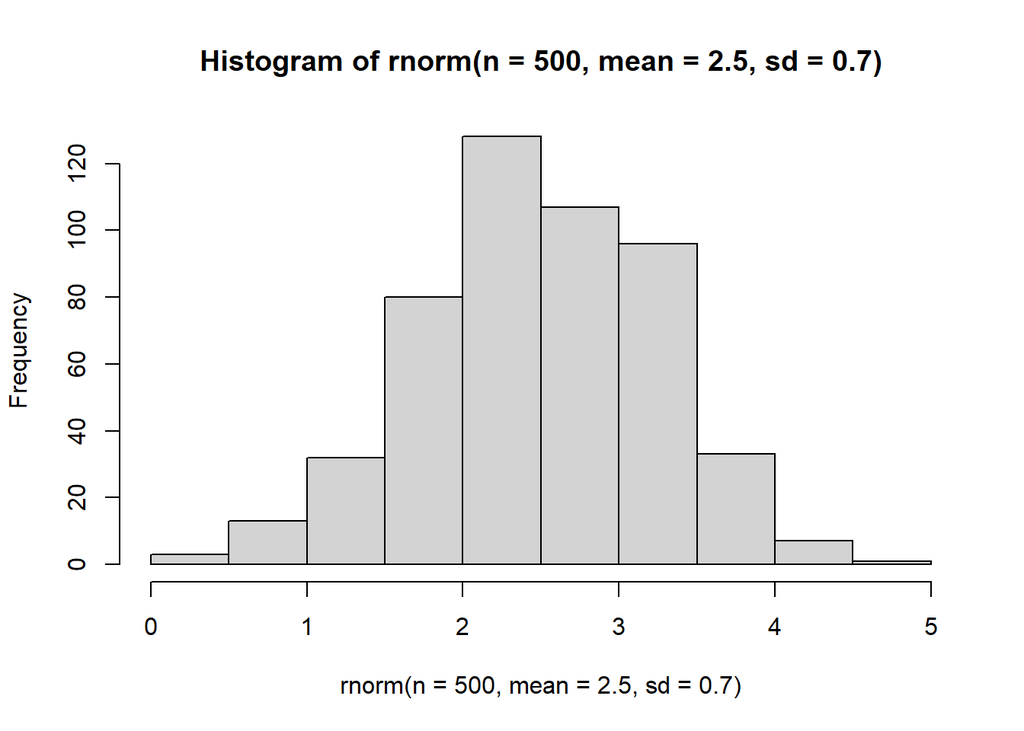

```r
# This will generate a histogram of a random normal distribution.
hist(
  # `rnorm` produces n random draws that requires two moments: mean and standard deviation.
  rnorm(
    # The number of draws
    n = 500,
    # The mean, or average, which is where a normal distribution is centred.
    mean = 2.5,
    # The standard deviation, or spread of a distribution. We'll talk about it more shortly.
    sd = .7)
)
```

# Investigating Scores

Now that we’ve discussed some ways to inspect data, let’s talk about summarizing it. As noted above, mean and standard deviation are useful ways to summarize many distributions. They also have very easy to remember functions in R: `mean` gives you an arithmetic mean, and `sd` computes standard deviations. To start, let’s look at how you can obtain them. This first method is a way to obtain as many summary statistics of numeric data as possible, but it doesn’t work. What is the error?

```r
training_data %>%
  summarise(duration_mean = mean(duration_in_seconds),
            duration_sd = sd(duration_in_seconds),
            burnout1_mean = mean(burnout1),
            burnout1_sd = sd(burnout1))
```

```
## # A tibble: 1 × 4
##   duration_mean duration_sd burnout1_mean burnout1_sd
##           <dbl>       <dbl>         <dbl>       <dbl>
## 1         3352.      27759.            NA          NA
```

Many of our variable has missing data. R’s default is to not anticipate msising data. This is a good thing! It can be annoying, but not knowing you have missing data is a problem. That being said, you still need a way to obtain summary statistics despite this! Here’s how you tell functions like `mean` and `sd` to ignore them:

```r
training_data %>%
  summarise(duration_mean = mean(duration_in_seconds),
            duration_sd = sd(duration_in_seconds),
            burnout1_mean = mean(burnout1, na.rm = TRUE),
            burnout1_sd = sd(burnout1, na.rm = TRUE))
```

```
## # A tibble: 1 × 4
##   duration_mean duration_sd burnout1_mean burnout1_sd
##           <dbl>       <dbl>         <dbl>       <dbl>
## 1         3352.      27759.          3.17        1.72
```

We can also use the `group_by` Tidyverse function to get these estimates by group:

```r
training_data %>%
  group_by(leo) %>%
  summarise(duration_mean = mean(duration_in_seconds),
            duration_sd = sd(duration_in_seconds),
            burnout1_mean = mean(burnout1, na.rm = TRUE),
            burnout1_sd = sd(burnout1, na.rm = TRUE))
```

```
## # A tibble: 2 × 5
##   leo   duration_mean duration_sd burnout1_mean burnout1_sd
##   <fct>         <dbl>       <dbl>         <dbl>       <dbl>
## 1 0             1221.       1760.          2.66        1.51
## 2 1             3995.      31642.          3.32        1.76
```

### A brief stats lesson: Standard Deviation & IQR, Simple Measures of Spread

#### Standard Deviation

Standard deviation is a measure of data dispersal. The higher it is, the further spread apart data points are. It’s also the square root of variance. See the image and equation below.
$$\sigma = \sqrt{\sigma^2} = \sqrt{\frac{\Sigma(x_i - \mu)^2}{N}}$$

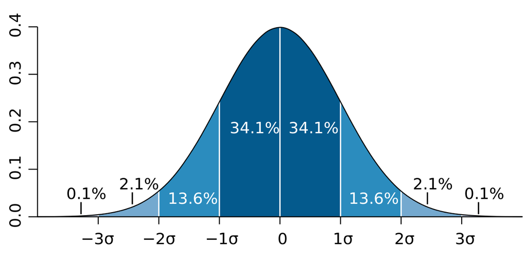

sd image

#### Interquartile Range

The interquartile range is another measure of dispersion. It is much more applicable to medians rather than means, but it can also be useful. Here is how it is calculated:

```r
x <- seq(1:10)
x
```

```
##  [1]  1  2  3  4  5  6  7  8  9 10
```

```r
median(x)
```

```
## [1] 5.5
```

```r
quantile(x)
```

```
##    0%   25%   50%   75%  100%
##  1.00  3.25  5.50  7.75 10.00
```

```r
7.75-3.25
```

```
## [1] 4.5
```

```r
IQR(x)
```

```
## [1] 4.5
```

## An alternative summarization

```r
training_data %>%
  pivot_longer(burnout1:burnout9) %>%

  group_by(name) %>%
  summarize(mean = mean(value, na.rm = TRUE),
            sd = sd(value, na.rm = TRUE),
            med = median(value, na.rm = TRUE),
            IQR = IQR(value, na.rm = TRUE))
```

```
## # A tibble: 9 × 5
##   name      mean    sd   med   IQR
##   <chr>    <dbl> <dbl> <dbl> <dbl>
## 1 burnout1  3.17  1.72     3     2
## 2 burnout2  2.94  1.78     2     2
## 3 burnout3  2.34  1.53     2     2
## 4 burnout4  2.85  1.92     2     3
## 5 burnout5  1.62  1.25     1     1
## 6 burnout6  1.56  1.06     1     1
## 7 burnout7  3.45  1.88     4     3
## 8 burnout8  4.28  1.94     4     4
## 9 burnout9  4.37  1.94     4     3
```

## Sum Scores

```r
with(training_data,
     rowSums(cbind(burnout1, burnout2, burnout3,
                   burnout4, burnout5, burnout6,
                   burnout7, burnout8, burnout9), na.rm = TRUE)
)
```

```
##   [1] 29 30 34 15 22 27 29 31 29 31 35 21 20 30 22 22 39 25 24 34 33 28 30 22 26
##  [26] 33 16 19 15 26 45 31 32 52 36 24 28 24 24 51 16  9 27 27 39 25 19 18 23  9
##  [51] 26 25 20 43 28 25  9 21 23 24 16 20 24 30 22 19 26 30 29 39 20 21 28 24 32
##  [76] 19 33 17 15 30 11 21 22 24 27 17 39 27 33 37 29 21 29 20 23 27 33 35 30 28
## [101] 24 25 39 30 30 18 19 24 29 25  0 21 16 21 37 27 30 36 20 19 38 42 27 15  0
## [126] 28 19 27 27 21 31 18 38 27 36 16 20 26  9 28 33 21 43 21 39 18 25 35 16 31
## [151] 28 27  0 24 14 20 50 27 25 15 30 28 33 26 34 21  0 45 29 28 25 25 27 25  9
## [176] 25 43 30 27 29 25 24 13 18 24 27 28 36 26 40 43 17 13 29 32 23 43 24 18 33
## [201] 34  9  0 14 18 24 17 24 16 33 17 27 20 13 29 28 33 36 27 21 22 22 16 20 27
## [226] 19 14 40 25 26 31 41 24 31 25 30 38 22 26 20 21 35 27 32 33 28 23 20 27 27
## [251] 36  6 34 24 27 27 16 59 28 27 20  9 34 33 31 42 29 28 17 30 19 14 16 23 19
## [276] 33 20 25 26 28 39 19 19 30 18 36 33 11 28 18 37 15 32 30 29 18 30  9 19 29
## [301] 21 23 24 18 16 18 28 20 24 19 16 21 15 28 11 23 42 27 32 26 27 27 34 24 18
## [326] 35 21 32 21 27 35 19 22 46 18 16 27 32 28 32 30 26 36 28 18 32 34 17 18 37
## [351] 31 27 21 22 33 17 22 30 22 39 28 16 24 19 25 27 40 40 23 19 29 37 18 23 31
## [376] 17  9 29 38 27 15 19 30 18 29 24 34 22 24 38 36 31 22 15 29 34 44 29 48 38
## [401] 34 27 17 30 45 29 24 16 26 19 18 34  0 24 18 42 29 21 26 22 21 32 21 20 25
## [426] 23  0 35 31 44 43 35 22 33 27  0 27 40 31 30 36 27 38 36 24 30 40 20 24 29
## [451] 29 25 16 17 25 29 35 29 21 35 28 30 23 30 27 16 35 30 12 27 27 16 26 26 34
## [476] 31 26 40 14 22 30 36 24 25 30 19 23 22 29 23  0 37 33 22 27 18 49 37  0  0
```

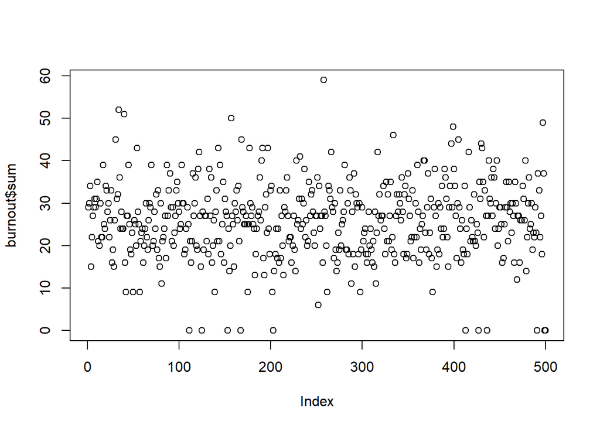

```r
burnout <- training_data %>%
  select(burnout1:burnout9)

burnout <- training_data %>%
  mutate(sum = rowSums(cbind(burnout1, burnout2, burnout3,
                              burnout4, burnout5, burnout6,
                              burnout7, burnout8, burnout9), na.rm = TRUE))

plot(burnout$sum)
```

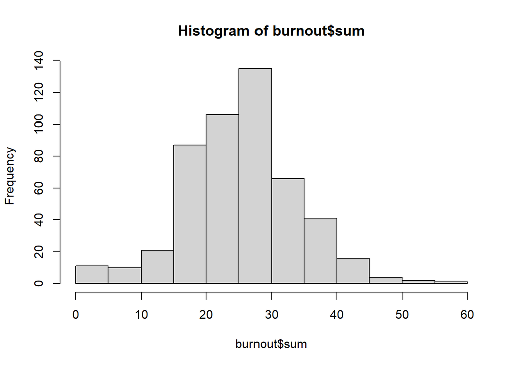

```r
hist(burnout$sum)
```

## Missing Data

```r
sum(complete.cases(training_data))
```

```
## [1] 383
```

```r
missing_pct <- function(data){
  # The total count of missing data
  sum(is.na(data))/
    # count of all data (missing + non-missing)
    (sum(is.na(data)+!is.na(data)))
}

missing_pct(training_data)
```

```
## [1] 0.01425
```

# Visualize

## Scatterplots

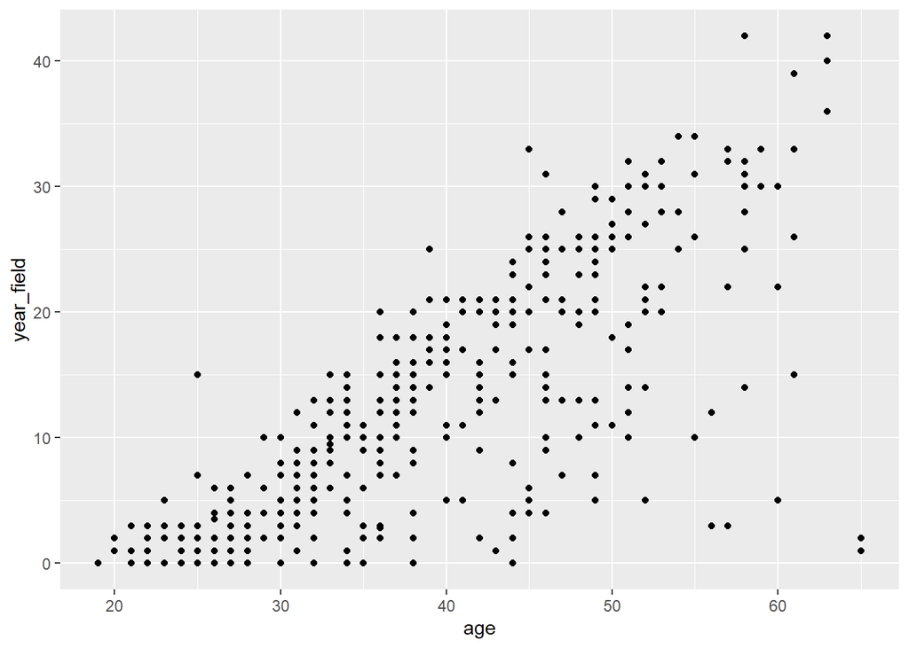

```r
training_data %>%
  ggplot() +
  geom_point(aes(x = age, y = year_field))
```

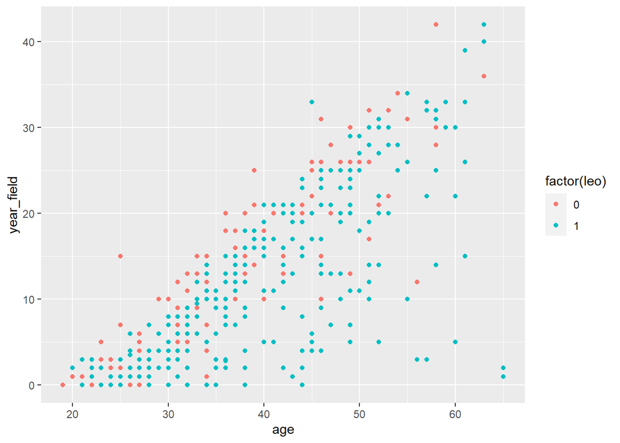

```r
training_data %>%
  ggplot() +
  geom_point(aes(x = age, y = year_field, color = factor(leo)))
```

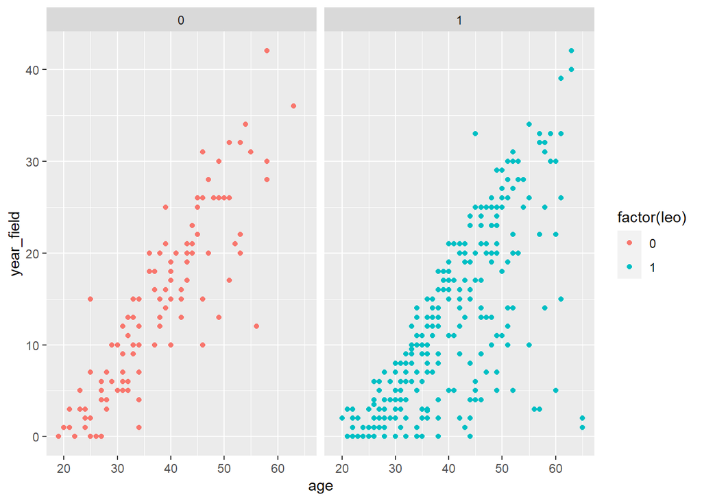

```r
training_data %>%
  ggplot() +
  geom_point(aes(x = age, y = year_field, color = factor(leo))) +
  facet_wrap(~ leo)
```

## Barcharts

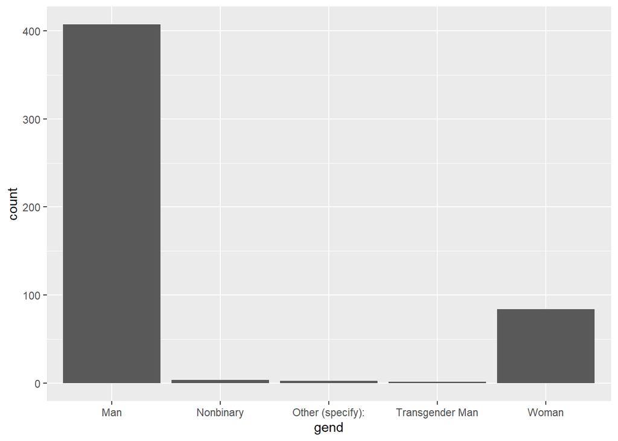

```r
training_data %>%
  ggplot() +
  geom_bar(aes(x = gend))
```

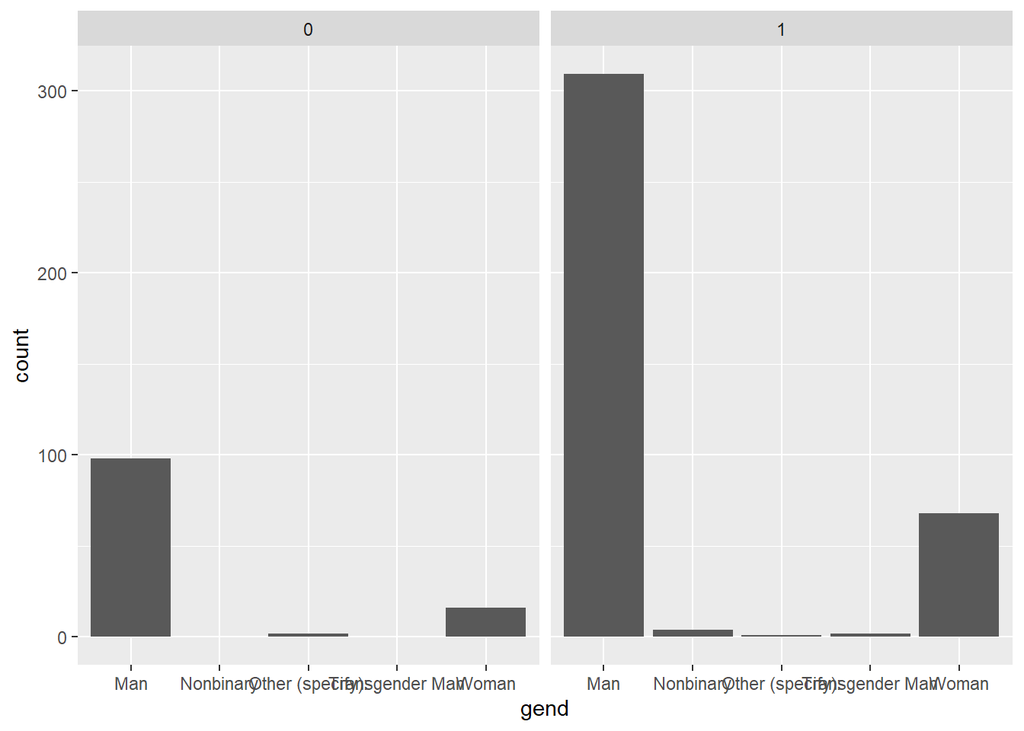

```r
training_data %>%
  ggplot() +
  geom_bar(aes(x = gend)) +
  facet_wrap(~ leo)
```

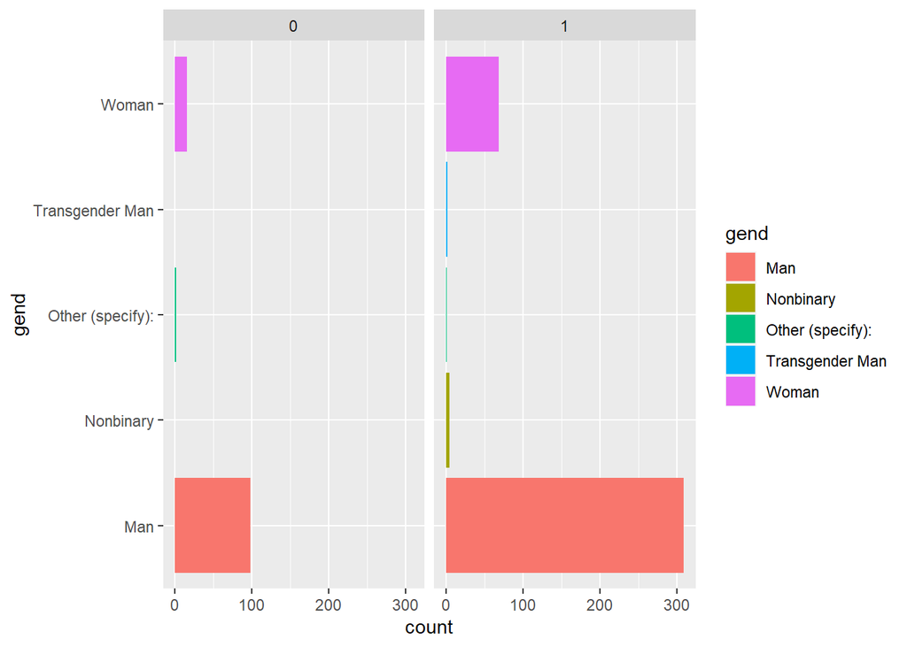

```r
training_data %>%
  ggplot() +
  geom_bar(aes(x = gend, fill = gend)) +
  facet_wrap(~ leo) +
  coord_flip()
```

## Box and Violin Plots

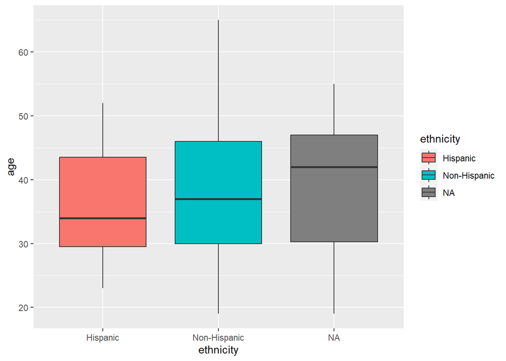

```r
training_data %>%
  ggplot() +
  geom_boxplot(aes(x = ethnicity, y = age, fill = ethnicity))
```

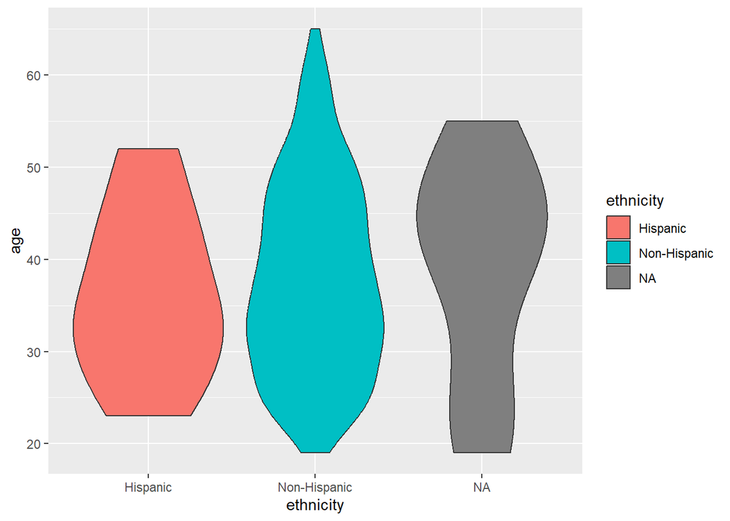

```r
training_data %>%
  ggplot() +
  geom_violin(aes(x = ethnicity, y = age, fill = ethnicity))
```

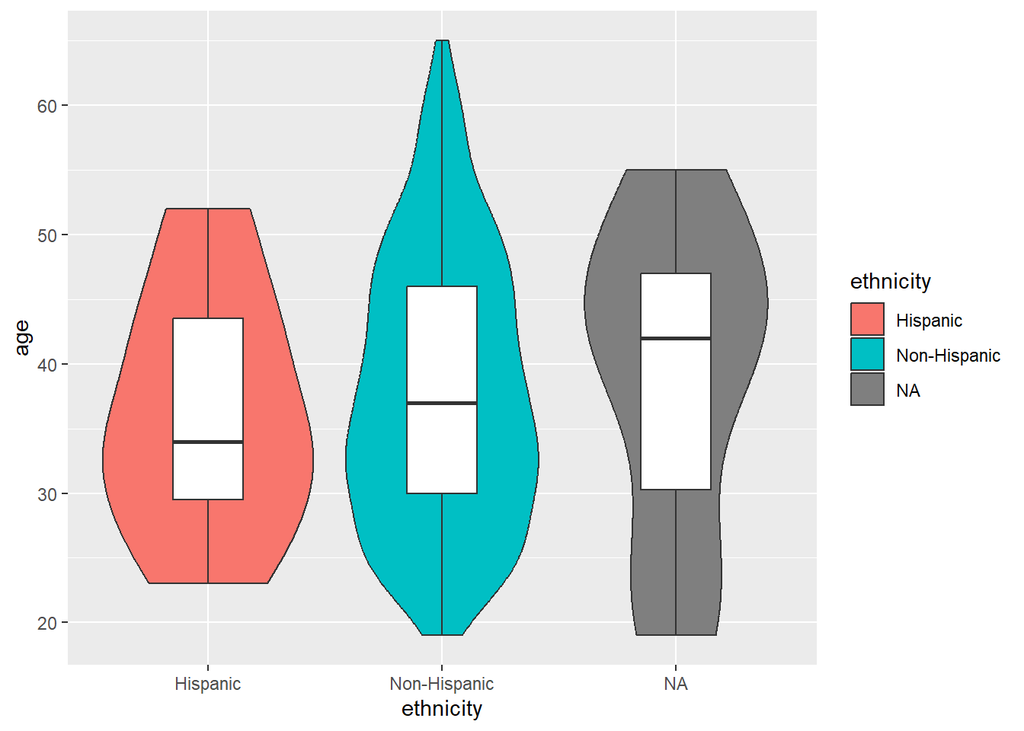

```r
training_data %>%
  ggplot() +
  geom_violin(aes(x = ethnicity, y = age, fill = ethnicity)) +
  geom_boxplot(aes(x = ethnicity, y = age), width = .3)
```

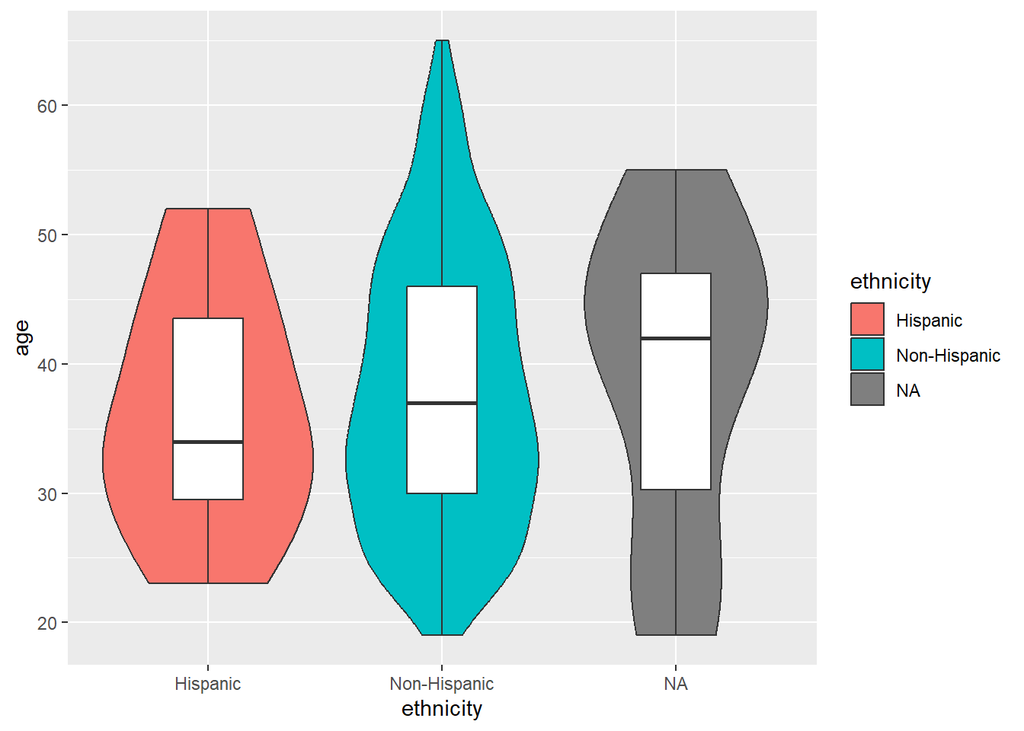

```r
training_data %>%
  ggplot(aes(x = ethnicity, y = age)) +
  geom_violin(aes(fill = ethnicity)) +
  geom_boxplot( width = .3)
```